# Creating example scenarios

Author

Galen Holt

```r
library(HydroBOT)
library(hydrogauge)
library(ggplot2)
library(sf)
library(dplyr)
```

# Overview

HydroBOT proper begins with hydrographs as inputs. The creation of those hydrographs, and particularly their modification to create scenarios is therefore typically a step that occurs prior to the use of HydroBOT. For the demonstrations here, however, we generate some example scenarios from historical hydrographs. For the purposes of capacity demonstration we simply multiply short hydrographs and put them in a standard HydroBOT input format here.

For this website, we use two sets of scenarios

1. The small set that comes with hydrobot itself, useful for examples that run the modules and aggregation steps
2. A larger set with more interesting structure, used for demonstrating the comparer. See information about them

This document generates that second set, which is mainly used to demonstrate the Comparer. Most other demonstrations just use the smaller set that comes with HydroBOT itself.

## HydroBOT relevance

The creation of flow scenarios is not part of HydroBOT proper. Instead, HydroBOT expects to ingest hydrographs and then handles the ongoing response models, aggregation, and analyses.

## Paths and other data

Set the data directory. These should usually point to external shared directories. For this simple example though, we put the data inside the repo to make it self contained.

```r
scenario_dir <- "more_scenarios"
hydro_dir <- file.path(scenario_dir, "hydrographs")
```

## Spatial datasets

We use spatial datasets provided by [{HydroBOT}](https://github.com/galenholt/HydroBOT), which provides a standard set. These are visualised in a separate notebook. Relevant to this scenario creation, we are interested in the gauges, (`HydroBOT::bom_basin_gauges`) since this is what were contained in the EWR tool. We use the `sdl_units` dataset to obtain a subset of gauges for these simple scenarios.

# Subset the gauges

We need multiple catchments for reasonable demonstration of spatial aggregation, so let’s use the Macquarie-Castlereagh, Namoi, Lachlan.

```r
catch_demo <- sdl_units |>
  dplyr::filter(SWSDLName %in% c("Macquarie-Castlereagh", "Lachlan", "Namoi"))
```

## Get relevant gauges

```r
demo_gauges <- st_intersection(bom_basin_gauges, catch_demo)
```

How many are there?

```r
demo_gauges |> nrow()
```

```
[1] 295
```

That’s a fair number, but they won’t all be in the EWR.

### Extract their names

To feed to the gauge puller, we need their gauge numbers.

```r
gaugenums <- demo_gauges$gauge
```

### Find those relevant to HydroBOT

We have the list of gauges, but now we need to cut the list down to those in the EWR tool. There’s not any point in pulling gauges that do not appear in the response model (here, the EWR tool).

```r
ewrs_in_pyewr <- get_ewr_table()
```

What are those gauges, and which are in both the ewr and the desired catchments?

```r
ewrgauges <- ewrs_in_pyewr$Gauge |> unique()
ewr_demo_gauges <- gaugenums[gaugenums %in% ewrgauges]
length(ewr_demo_gauges)
```

```
[1] 47
```

47 isn’t too many.

Need to categorise them so we know what to pull. Let’s cut to just flow gauges for the demo for simplicity- scaling levels is less clear.

```r
gauges_to_pull <- ewrs_in_pyewr |>
  filter(Gauge %in% ewr_demo_gauges & FlowLevelVolume == "F") |>
  dplyr::select(Gauge) |>
  unique() |>
  pull()
```

### Get all the gauge data

```r
starttime <- lubridate::ymd(20000701)
endtime <- lubridate::ymd(20210630)
```

Pull the data with [hydrogauge](https://galenholt.github.io/hydrogauge/)

```r
if (params$REBUILD_DATA) {
  demo_levs <- hydrogauge::get_ts_traces(
    portal = "NSW",
    site_list = gauges_to_pull,
    var_list = 141, # This is flow
    start_time = starttime,
    end_time = endtime
  )
}
```

This forcing should not be necessary, but some azure systems have old GDAL, which can’t read WKT2. Need to fix, but in the meantime, [force with the crs number](https://github.com/r-spatial/sf/issues/1419).

```r
if (grepl("npd-dat", Sys.info()["nodename"])) {
  st_crs(basin) <- 4283
  st_crs(catch_demo) <- 4283
  st_crs(demo_gauges) <- 4283
}
```

### Map the gauges

Looks reasonable. Probably overkill for testing, but can do a cut down version too.

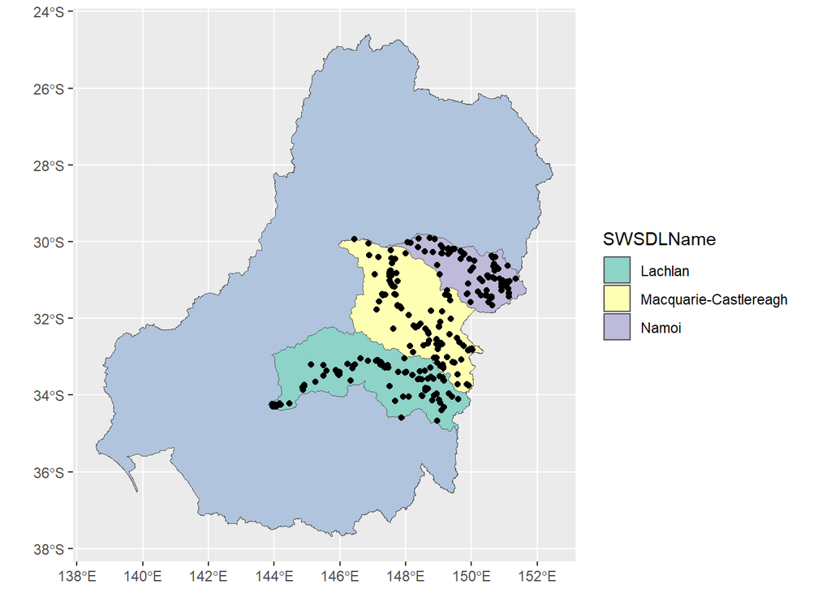

```r
(ggplot() +
  geom_sf(data = basin, fill = "lightsteelblue") +
  geom_sf(data = catch_demo, mapping = aes(fill = SWSDLName)) +
  geom_sf(data = demo_gauges, color = "black") +
  scale_fill_brewer(type = "qual", palette = 8))
```

# Make test scenarios

To generate simple scenarios that cover a range of flow conditions, we multiply and divide the baseline data by scaling factors, yielding symmetric changes up and down in relative flow. We also add ‘adaptation’ options as additions of flow during Sept-Dec.

### Make the data readable by EWR tool

The EWR tool has the capacity to pull gauge data directly, but because we have modified these data, they need to enter the EWR tool through `scenario_handling`, and so need to have a format the EWR tool can parse as output from one of the scenario generating tools it uses (IQQM, Source, etc). The current approach is to use `Standard time-series` as the type, which means we have to give the data the proper structure for that format.

This requries having a date column `Date` and other columns with gauge numbers for names, with ‘_flow’ or ‘_level’ after them. The EWR tool can have multiple gauges, with each having its own column. HydroBOT expects directories for each scenario, with any number of csvs of hydrographs inside, (e.g. it could be one csv with columns for each gauge, or each csv could have a single gauge), which is handled by `find_scenario_paths` internally to the “Scenario controller” part of HydroBOT. Here, we save a single csv with many gauges for each scenario.

### Build scenarios and data structure

Set up the data structure

```r
if (params$REBUILD_DATA) {
  demo_flow <- demo_levs |>
    dplyr::mutate(Date = lubridate::date(time)) |>
    # append the gauge type
    dplyr::mutate(site = paste0(site, "_flow")) |>
    dplyr::select(Date, value, site) |>
    tidyr::pivot_wider(
      id_cols = Date,
      names_from = site,
      values_from = value
    )
}
```

Now we want to set up the ‘scenarios’ as multiplications and additions, as well as the directory structure.

```r
multipliers <- c(1.1, 1.25, 1.5, 2)

scenemults <- c(1 / rev(multipliers), 1, multipliers)
climate_code <- LETTERS[1:length(scenemults)]

scenenames <- c(
  paste0("climatedown", as.character(rev(multipliers))),
  "climatebase",
  paste0("climateup", as.character(multipliers))
) |>
  stringr::str_replace("\\.", "_") # deals with the 1.x

adaptadds <- c(0, 250, 6500, 12000)
adapt_code <- 1:length(adaptadds)

adapttime <- 8 # months = Sep,Oct,Nov,Dec

sceneaddsnames <- c(paste0("adapt", as.character(adaptadds))) |>
  stringr::str_replace("\\.", "_")

scenenames <- paste0(
  rep(scenenames,
    times = length(unique(adaptadds))
  ),
  stringr::str_sort(
    rep(sceneaddsnames,
      times = length(unique(scenemults))
    ),
    numeric = TRUE
  )
)

scenemults <- rep(scenemults, times = length(unique(sceneaddsnames)))
climate_code <- rep(climate_code, times = length(unique(sceneaddsnames)))

sceneadds <- sort(rep(adaptadds, times = length(unique(scenemults))))
adapt_code <- sort(rep(adapt_code, times = length(unique(scenemults))))
sceneadapttimes <- rep(adapttime, times = length(scenenames))

scenario_code <- paste0(climate_code, adapt_code)


# Add in the MAX scenario
scenenames <- c(scenenames, "MAX")
scenemults <- c(scenemults, 0)
sceneadds <- c(sceneadds, 500000)
sceneadapttimes <- c(sceneadapttimes, 0)
climate_code <- c(climate_code, "MAX")
adapt_code <- c(adapt_code, Inf)
scenario_code <- c(scenario_code, "MAX")

check <- data.frame(scenenames = scenenames)
check$scenemults <- scenemults
check$sceneadds <- sceneadds
check$sceneadapttimes <- sceneadapttimes

# the full scenarios
for (x in scenenames) {
  scenedir <- file.path(hydro_dir, x)
  if (!dir.exists(scenedir)) {
    dir.create(scenedir, recursive = TRUE)
  }
}
```

Create clean dataframes to save. Could be fancy with a function and a purr, but we’re just saving, so a simple loop should be fine.

HydroBOT does not *write* scenario metadata, since the scenarios will come from elsewhere. Instead, in an ideal world, scenarios will come with metadata. Here, since we’re creating the scenarios, make some metadata here.

```r
if (params$REBUILD_DATA) {
  for (i in 1:length(scenenames)) {
    demo_flow |>
      dplyr::mutate(across(-Date, \(x) x * scenemults[i])) |>
      dplyr::mutate(across(-Date, \(x) ifelse(lubridate::month(Date) > sceneadapttimes[i],
        x + sceneadds[i], x
      ))) |>
      readr::write_csv(file.path(
        hydro_dir, scenenames[i],
        paste0(scenenames[i], ".csv")
      ))
    # make JSON metadata
    jsonlite::write_json(
      list(
        scenario_name = scenenames[i],
        flow_multiplier = scenemults[i],
        flow_addition = sceneadds[i],
        flow_addition_time = sceneadapttimes[i]
      ),
      path = file.path(hydro_dir, scenenames[i], "metadata.json")
    )
  }
}
```

That set of hydrographs can now be used as starting data for a demonstration of HydroBOT proper.

Make some metadata for all scenarios too (both yaml and json).

```r
scenario_meta <- list(
  scenario = scenenames,
  flow_multiplier = scenemults,
  flow_addition = sceneadds,
  flow_addition_time = sceneadapttimes,
  climate_code = climate_code,
  adapt_code = adapt_code,
  scenario_code = scenario_code
)

# I don't know the format we'll be using, but this works to create yaml metadata
yaml::write_yaml(scenario_meta,
  file = file.path(hydro_dir, "scenario_metadata.yml")
)
# and this does the same with JSON
jsonlite::write_json(scenario_meta,
  path = file.path(hydro_dir, "scenario_metadata.json")
)
```